# GroupTrack — User Manual

What does it mean to me?

Everyone knows who leads, who sweeps and who is on the air — and roles change at a stop in seconds.

**More: Roles on the trail**

Your role is chosen when you check in — Leader, Rider, Middle or Tail gunner — for that ride only. Everyone is a Rider unless they check in as Leader, Middle or Tail gunner; their tablets tell the group over the radio, so every cart learns who holds each role. You see every cart's callsign and role beside it on the map and in this list; the lead and tail markers follow the riders who hold those roles.

- **One of each.** One Leader, one Middle and one Tail gunner at most; any number of Riders. The Leader's cart is the lead cart. With no Tail gunner, the last cart is the tail.
- **Each rider sets only their own role.** A role someone holds can't be taken until it is released. To hand over the lead at a stop: the Leader changes to Rider, then the new Leader takes Leader. Every tablet follows within seconds.
- **Roles show only while you are checked in**, and end with the ride. A cart that drops out of range keeps its role.
- **Two claims of one role** at the same moment — both go back to Rider, and a flashing red ROLE CONFLICT message says so. Agree who takes it; that rider claims it again.
- **No Leader yet?** When recording starts with no Leader known, GroupTrack asks which cart leads — on your tablet only. As soon as a Leader is heard, the lead moves to them.

Carried from the 2.7b manual — check the wording.

**Create a ride**

What is it?

Makes a ride from one of your routes: name, date and rollout time, route, trailhead, maps and radio network.

How do I use it?

Rides › **Create a ride**, then follow the screens below. GroupTrack looks for trailheads within ½ mile (2,640 ft) of the route's start: one is used, several give you a choice, none — you describe where to meet. Only the name is needed to save; the ride can be sent once it is complete.

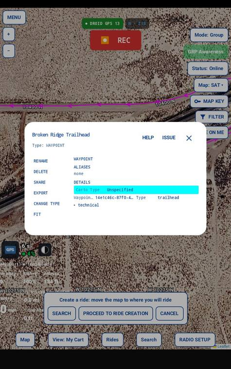

Search result obtained and map position, select proceed to add a ride

**Search** for the area; the map moves there. Tap **PROCEED**.

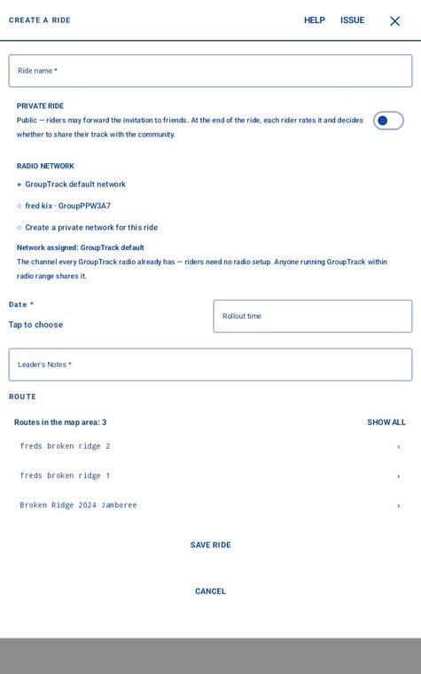

Create a ride after search positioning

The new ride, ready to fill in.

[figure not shown]

Ride creation

Name the ride and choose public or private and the radio network.

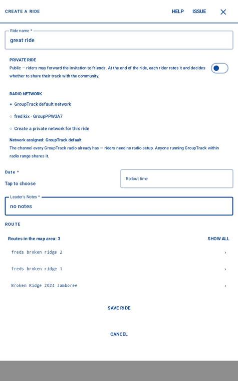

Complete the required fields then select your desired route in the area you have searched

Fill in the required fields, then tap the **route** from those in the map area.

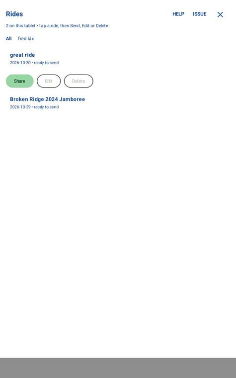

Date and time supplied now ride is complete

Add the **date and rollout time**: the ride is complete and can be sent.